# Gráficos finais Vacina.edu

Jonas Coelho

19/08/2021

Este arquivo possui exemplos dos gráficos a serem gerados para o site Vacina.edu.

Serão três seções de gráficos distintas, descritas abaixo. As exibições são meramente exemplos, não necessitando que sejam seguidas à risca.

```r
# Bibliotecas usadas para gerar exemplos
library(dplyr)
library(ggplot2)
library(geobr)
library(sf)

library(crul)

library(hrbrthemes)

no_axis <- theme(axis.title=element_blank(),
                   axis.text=element_blank(),
                   axis.ticks=element_blank())
```

# 1 Proporção de funcionários vacinados

Essa primeira parte seriam dois gráficos, alternáveis por meio de boxes em que o usuário possa clicar e alternar a visualização. O primeiro gráfico é um gráfico de barras empilhadas com a proporção de profissionais da educação básica imunizados. Uma barra corresponde ao valor de primeiras doses distribuídas no estado (imunização parcial) enquanto a outra barra corresponde à soma de segundas doses + doses únicas (imunização completa).

- Os valores seriam apresentados agregados por estados.
- O eixo X iria de 0 a 100%
- O eixo Y seriam os estados, ordenados pela proporção de imunizados parcialmente (em caso de empate, pela proporção de imunizados completamente)
- As cores das barras são as seguintes: imunização completa (#083550), imunização parcial (#1F95E1)
- No caso de estados em que há mais de 100% de imunização parcial (há alguns casos), o gráfico caparia no limite de 100%, mas mostraria o valor real quando o usuário passasse o mouse por cima

```r
tabela_final <- readr::read_csv("../dados/outputs/tabela_final2021-08-18.csv")

lista_capitais <- c('1100205', '1302603', '1200401', '5002704', '1600303', '5300108', '1400100', '5103403', '1721000', '3550308', '2211001', '3304557', '1501402', '5208707', '2927408', '4205407', '2111300', '2704302', '4314902', '4106902', '3106200', '2304400', '2611606', '2507507', '2800308', '2408102', '3205309')

graf1 <- tabela_final %>%
group_by(uf) %>%
summarise(total_educ_basic = sum(total_educ_basic), prim_dose = sum(prim_dose), completa = sum(segun_dose+dose_unica)) %>%
mutate(imun_parcial = prim_dose/total_educ_basic, imun_completa = completa/total_educ_basic)

graf2 <- graf1 %>%
  mutate(local = 'Estado')

capitais <- tabela_final %>%
filter(id_municipio %in% lista_capitais) %>%
rowwise() %>%
mutate(local = 'Capital', completa = segun_dose+dose_unica) %>%
select(uf, local, total_educ_basic, prim_dose, completa) %>%
mutate(imun_parcial = prim_dose/total_educ_basic, imun_completa = completa/total_educ_basic) %>%
rbind(graf2)
```

## 1.1 Somente estados

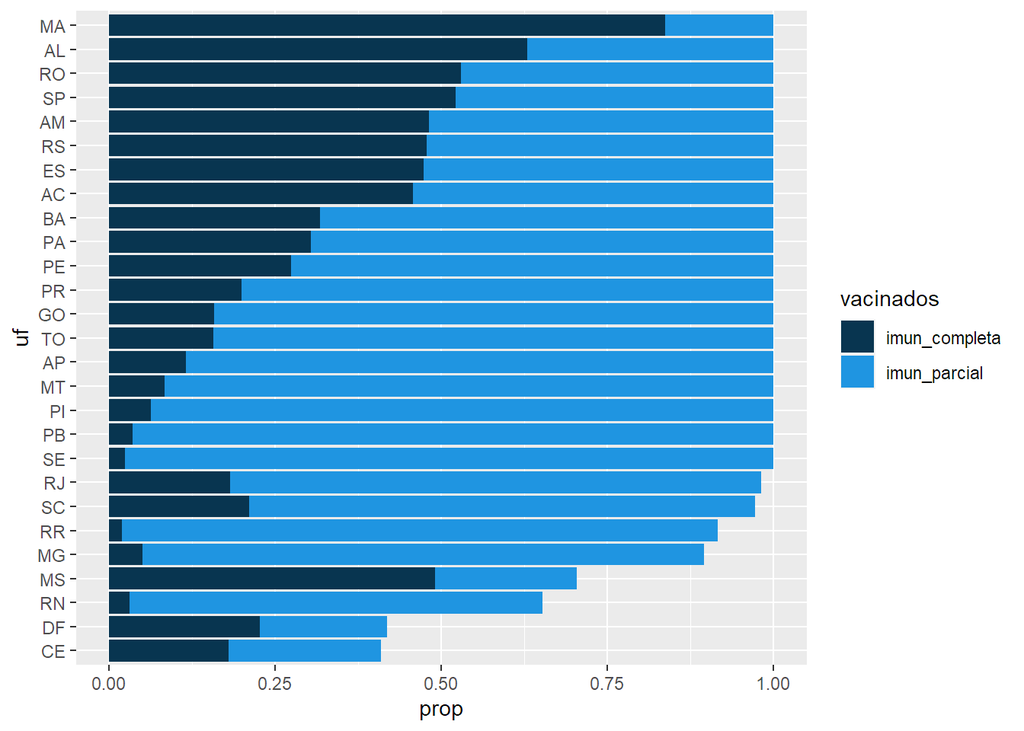

```r
 graf1 %>%
  select(uf, imun_parcial, imun_completa) %>%
  mutate(ordem = ifelse(imun_parcial>1, 5+imun_completa, imun_parcial)) %>%
  mutate(uf = forcats::fct_reorder(uf, ordem)) %>%
  select(!ordem) %>%
  tidyr::pivot_longer(!uf, names_to = 'vacinados', values_to = 'prop') %>%
  mutate(prop = ifelse(prop>1,1,prop)) %>%
  ggplot(aes(fill=vacinados, y=uf, x=prop)) +
  geom_bar(stat="identity", position = "identity") +
  scale_fill_manual(values=c("#083550", "#1F95E1"))
```

## 1.2 Estados e capitais

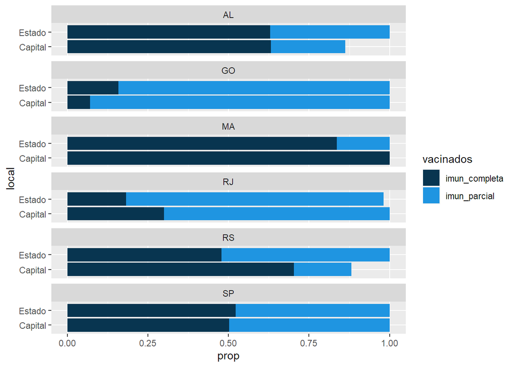

```r
capitais %>%
  select(uf, local, imun_parcial, imun_completa) %>%
  filter(uf %in% c('RJ', 'SP', 'AL', 'MA', 'RS', 'GO')) %>%
  tidyr::pivot_longer(!c(uf, local), names_to = 'vacinados', values_to = 'prop') %>%
  mutate(prop = ifelse(prop>1,1,prop)) %>%
  ggplot(aes(fill=vacinados, y=local, x=prop)) +
  scale_fill_manual(values=c("#083550", "#1F95E1")) +
  geom_bar(stat="identity", position = "identity") +
  facet_wrap(~ uf, ncol = 1)
```

# 2 Infraestrutura - Estados

Essa segunda parte pretende apresentar a proporção (em %) de escolas em cada estado que não possui a) água potável, b) área verde e c) pátio descoberto. Os gráficos serão gerados a partir de mapas, com escala monocromática indo do valor mínimo ao máximo entre cada estado. O usuário poderá trocar entre os três tipos diferentes ao clicar em ‘boxes’ acima do gráfico.

```r
load('../apps/dados/states.RData')
load('../apps/dados/sumario3.rdata')
load('../apps/dados/sumario_capitais.RData')

equivalencias <- data.frame(co_uf = c('12', '27', '13', '16', '29', '23', '53', '32', '52', '21', '31', '50', '51', '15', '25', '26', '22', '41', '33', '24', '11', '14', '43', '42', '28', '35', '17'), uf = c('AC', 'AL', 'AM', 'AP', 'BA', 'CE', 'DF', 'ES', 'GO', 'MA', 'MG', 'MS', 'MT', 'PA', 'PB', 'PE', 'PI', 'PR', 'RJ', 'RN', 'RO', 'RR', 'RS', 'SC', 'SE', 'SP', 'TO'))
```

## 2.1 Água potável

A escala desse mapa deverá ser na cor azul.

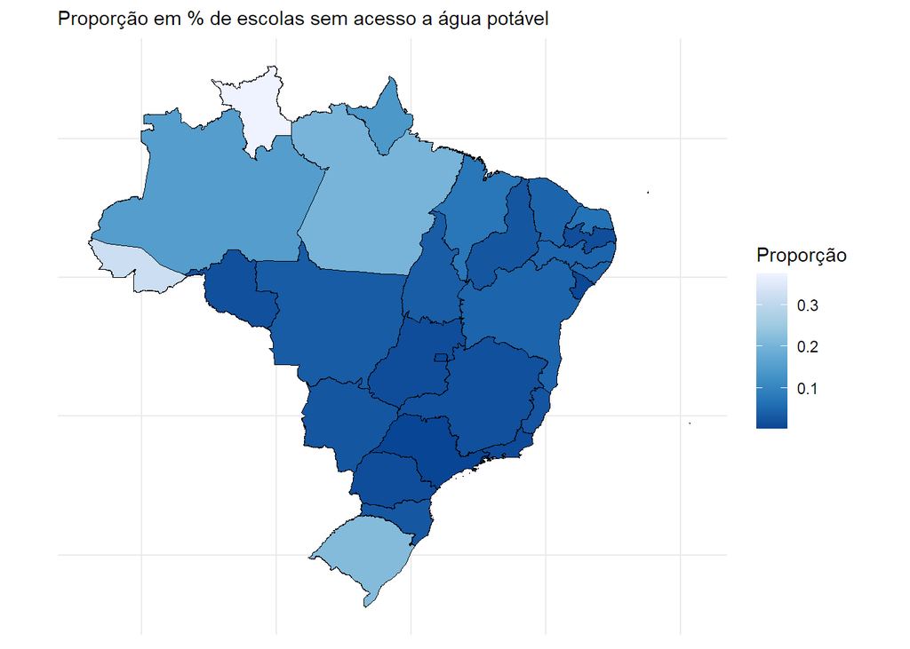

```r
states %>%
  filter(coluna == 'in_agua_potavel') %>%
  mutate(prop_preenchida_sem_agua = zeros/(zeros+uns)) %>%
  ggplot() +
    geom_sf(aes(fill=prop_preenchida_sem_agua), color= '#000000', size=.15) +
      labs(subtitle="Proporção em % de escolas sem acesso a água potável", size=8) +
      scale_fill_distiller(direction = -1, name="Proporção") +
      theme_minimal() +
      no_axis
```

## 2.2 Área verde

A escala desse mapa deverá ser na cor verde.

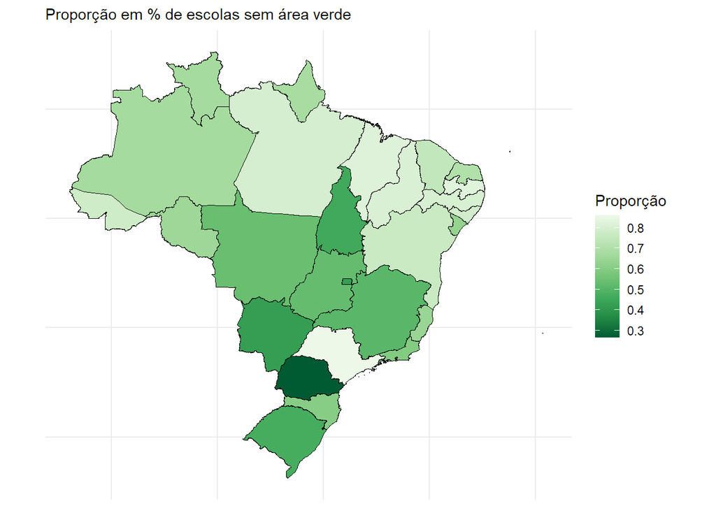

```r
states %>%
  filter(coluna == 'in_area_verde') %>%
  mutate(prop_preenchida_sem_agua = zeros/(zeros+uns)) %>%
  ggplot() +
    geom_sf(aes(fill=prop_preenchida_sem_agua), color= '#000000', size=.15) +
      labs(subtitle="Proporção em % de escolas sem área verde", size=8) +
      scale_fill_distiller(direction = -1, palette = "Greens", name="Proporção") +
      theme_minimal() +
      no_axis
```

## 2.3 Pátio descoberto

A escala desse mapa deverá ser na cor laranja.

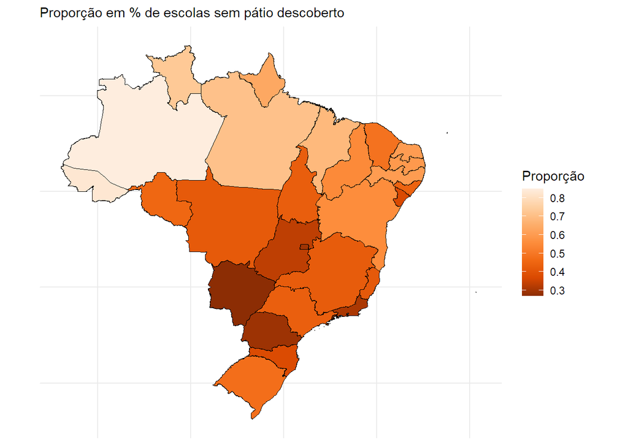

```r
states %>%
  filter(coluna == 'in_patio_descoberto' | coluna == 'in_patio_coberto') %>%
  group_by(co_uf) %>%
  summarise(soma_zeros = sum(zeros),
            soma_uns = sum(uns)) %>%
  mutate(prop_preenchida_sem_agua = soma_zeros/(soma_zeros+soma_uns)) %>%
  ggplot() +
    geom_sf(aes(fill=prop_preenchida_sem_agua), color= '#000000', size=.15) +
      labs(subtitle="Proporção em % de escolas sem pátio descoberto", size=8) +
      scale_fill_distiller(direction = -1, palette = "Oranges", name="Proporção") +
      theme_minimal() +
      no_axis
```

# 3 Infraestrutura - Capitais e Estados

Nessa seção, será apresentada a diferença entre os valores anteriores por estado e o valor obtido pela sua respectiva capital, em três Lollipop charts distintos. Os estados serão representados por pontos com a cor #083550 e as capitais por pontos com a cor #1f95e1. Ambos deverão estar levemente transparentes para melhor evidenciar casos de sobreposição. Os estados estão ordenados por diferença entre o valor da capital e o valor do estado. Quanto “pior” a capital, mais para cima no ordenamento, quanto “melhor”, mais para baixo. O usuário poderá trocar entre os três tipos diferentes ao clicar em ‘boxes’ acima do gráfico.

## 3.1 Água potável

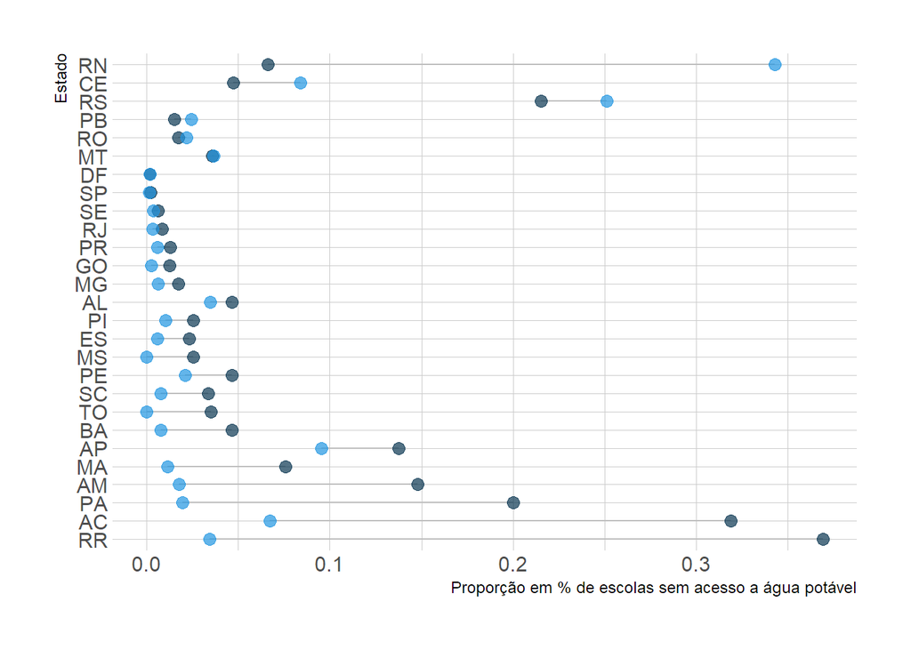

```r
temp1 <- sumario3 %>%
  left_join(equivalencias) %>%
  filter(coluna == 'in_agua_potavel') %>%
  mutate(prop_preenchida_sem_agua = zeros/(zeros+uns)) %>%
  select(uf, prop_preenchida_sem_agua) %>%
  rename(valor_estado = prop_preenchida_sem_agua)

temp2 <- sumario_capitais %>%
  left_join(equivalencias) %>%
  filter(coluna == 'in_agua_potavel') %>%
  mutate(prop_preenchida_sem_agua = zeros/(zeros+uns)) %>%
  select(uf, prop_preenchida_sem_agua) %>%
  rename(valor_capital = prop_preenchida_sem_agua)

temp3 <- temp1 %>%
  left_join(temp2) %>%
  rowwise() %>%
  mutate(mymean = mean(c(valor_estado,valor_capital) ), dif = valor_estado-valor_capital) %>%
  arrange(desc(dif)) %>%
  mutate(uf=factor(uf, uf))

ggplot(temp3) +
  geom_segment( aes(x=uf, xend=uf, y=valor_estado, yend=valor_capital), color="grey") +
  geom_point( aes(x=uf, y=valor_estado), color='#083550', size=3, alpha = 0.7) +
  geom_point( aes(x=uf, y=valor_capital), color='#1f95e1', size=3, alpha = 0.7) +
  coord_flip()+
  theme_ipsum() +
  theme(
    legend.position = "none",
  ) +
  xlab("Estado") +
  ylab("Proporção em % de escolas sem acesso a água potável")
```

## 3.2 Área verde

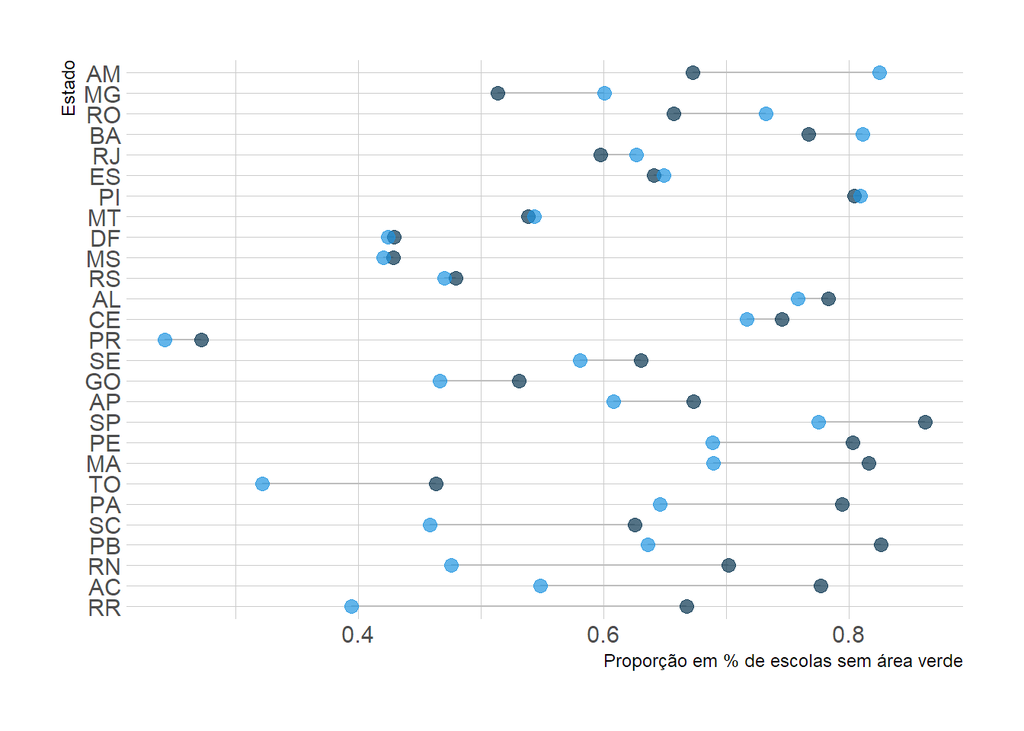

```r
temp1 <- sumario3 %>%
  left_join(equivalencias) %>%
  filter(coluna == 'in_area_verde') %>%
  mutate(prop_preenchida_sem_agua = zeros/(zeros+uns)) %>%
  select(uf, prop_preenchida_sem_agua) %>%
  rename(valor_estado = prop_preenchida_sem_agua)

temp2 <- sumario_capitais %>%
  left_join(equivalencias) %>%
  filter(coluna == 'in_area_verde') %>%
  mutate(prop_preenchida_sem_agua = zeros/(zeros+uns)) %>%
  select(uf, prop_preenchida_sem_agua) %>%
  rename(valor_capital = prop_preenchida_sem_agua)

temp3 <- temp1 %>%
  left_join(temp2) %>%
  rowwise() %>%
  mutate(mymean = mean(c(valor_estado,valor_capital) ), dif = valor_estado-valor_capital) %>%
  arrange(desc(dif)) %>%
  mutate(uf=factor(uf, uf))

ggplot(temp3) +
  geom_segment( aes(x=uf, xend=uf, y=valor_estado, yend=valor_capital), color="grey") +
  geom_point( aes(x=uf, y=valor_estado), color='#083550', size=3, alpha = 0.7) +
  geom_point( aes(x=uf, y=valor_capital), color='#1f95e1', size=3, alpha = 0.7) +
  coord_flip()+
  theme_ipsum() +
  theme(
    legend.position = "none",
  ) +
  xlab("Estado") +
  ylab("Proporção em % de escolas sem área verde")
```

## 3.3 Pátio descoberto

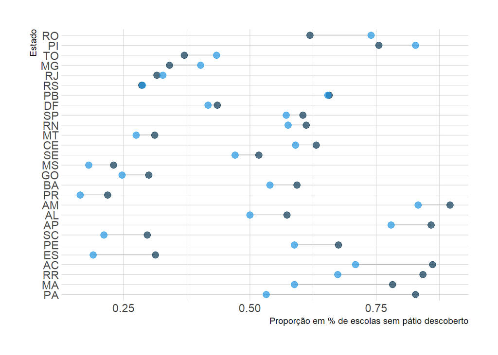

```r
temp1 <- sumario3 %>%
  left_join(equivalencias) %>%
  filter(coluna == 'in_patio_descoberto') %>%
  mutate(prop_preenchida_sem_agua = zeros/(zeros+uns)) %>%
  select(uf, prop_preenchida_sem_agua) %>%
  rename(valor_estado = prop_preenchida_sem_agua)

temp2 <- sumario_capitais %>%
  left_join(equivalencias) %>%
  filter(coluna == 'in_patio_descoberto') %>%
  mutate(prop_preenchida_sem_agua = zeros/(zeros+uns)) %>%
  select(uf, prop_preenchida_sem_agua) %>%
  rename(valor_capital = prop_preenchida_sem_agua)


temp3 <- temp1 %>%
  left_join(temp2) %>%
  rowwise() %>%
  mutate(mymean = mean(c(valor_estado,valor_capital) ), dif = valor_estado-valor_capital) %>%
  arrange(desc(dif)) %>%
  mutate(uf=factor(uf, uf))

ggplot(temp3) +
  geom_segment( aes(x=uf, xend=uf, y=valor_estado, yend=valor_capital), color="grey") +
  geom_point( aes(x=uf, y=valor_estado), color='#083550', size=3, alpha = 0.7, show.legend=TRUE) +
  geom_point( aes(x=uf, y=valor_capital), color='#1f95e1', size=3, alpha = 0.7, show.legend=TRUE) +
  coord_flip()+
  theme_ipsum() +
  theme(legend.position = "none") +
  xlab("Estado") +
  ylab("Proporção em % de escolas sem pátio descoberto")
```